# The Complete Guide to Bar Graphs in R

Data Visualization

Author: Alejandra Sarria

Data Analyst | Data Scientist | Analytics translator | Specialist in Data-Driven Decision Making

2025-03-13

**LinkedIn:** www.linkedin.com/in/alejandrasarria

[figure not shown]

# 1 Introduction

This comprehensive guide expands on our beginner’s introduction to bar graphs in R, diving deeper into **customization and advanced techniques**. While creating a basic bar graph with ggplot2 is straightforward, refining its aesthetics, improving readability, and adding interactive elements can **elevate your visualizations** to a professional level. Here, we will explore color customization, label formatting, legend adjustments, axis modifications, and even integrating images into bar graphs. Whether you’re preparing reports, presentations, or dashboards, these techniques will help you create visually compelling and highly informative bar charts.

# 2 Our database

For this tutorial, we will use the gapminder dataset. This dataset is included in the `gapminder` package in R and contains information about country-level economic and demographic indicators from 1952 to 2007, recorded at five-year intervals. It includes six key variables:

- **Country** (Name of the country)
- **Continent** (Continent the country belongs to)
- **Year** (Year of the observation)
- **LifeExp** (Life expectancy at birth, in years)
- **Pop** (Total population of the country)
- **gdpPercap** (Gross domestic product per capita, in USD)

In this tutorial, we will focus on the continent variable to demonstrate how to create bar graphs in R, customize them for better readability, and enhance their presentation. Let´s load the database and the `ggplot2` package:

```r
#install.packages("ggplot2")
library(ggplot2)
library(dplyr)
library(gapminder)
data<- gapminder %>% filter(year==2007)
```

# 3 Create a basic bar graph

To create a basic bar graph using `ggplot2`, you can follow this example. This code creates a functional bar graph with the required layers: data, mapping with aes(), and the geometric object with geom_bar().

For in-depth information about `ggplot2` layers, I recommend reviewing the article “Visualizations with ggplot” which covers the fundamental components of `ggplot2`, including data layers, aesthetic mappings, and geometry functions. The article details how each layer contributes to constructing visualizations, providing examples that illustrate the power and flexibility of `ggplot2`.

Here’s a simple code snippet:

- `ggplot(data, aes(x = factor(continent)))`: Initializes a ggplot object using data and maps the continent variable to the x-axis as a factor.
- `geom_bar(...)`: Creates a bar chart.

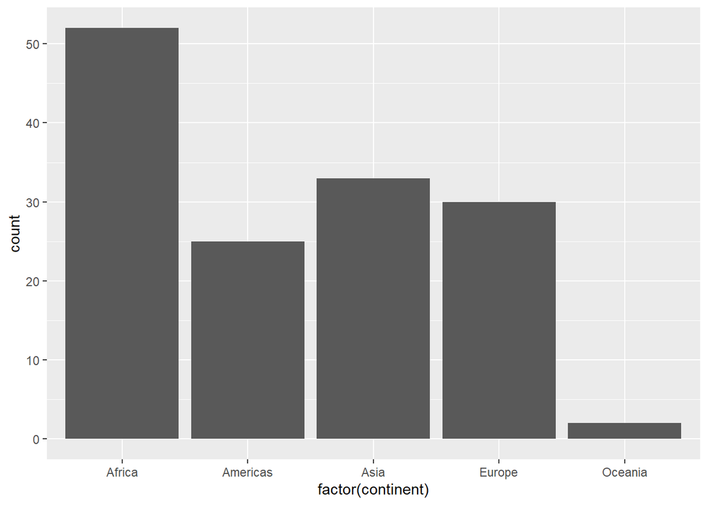

```r
# Create a bar chart using ggplot2
graph1 <- ggplot(data, aes(x = factor(continent))) +
  geom_bar()

graph1
```

# 4 Customizing Bar Width and Color

In ggplot2, **width** is used to changes the width of the bars in a bar chart, which can enhance overall aesthetics by preventing overcrowding. The **color** parameter specifies the border color of the bars, allowing for better visual distinction. The **fill** parameter changes the interior color of the bars.

- `width = 0.4` → Reduces the default bar width to 40% of the available space.
- `color = "#1f77b4"` → Sets the bar border color to blue (#1f77b4).
- `fill = "#1f77b4"` → Fills the bar interior with the same blue color.

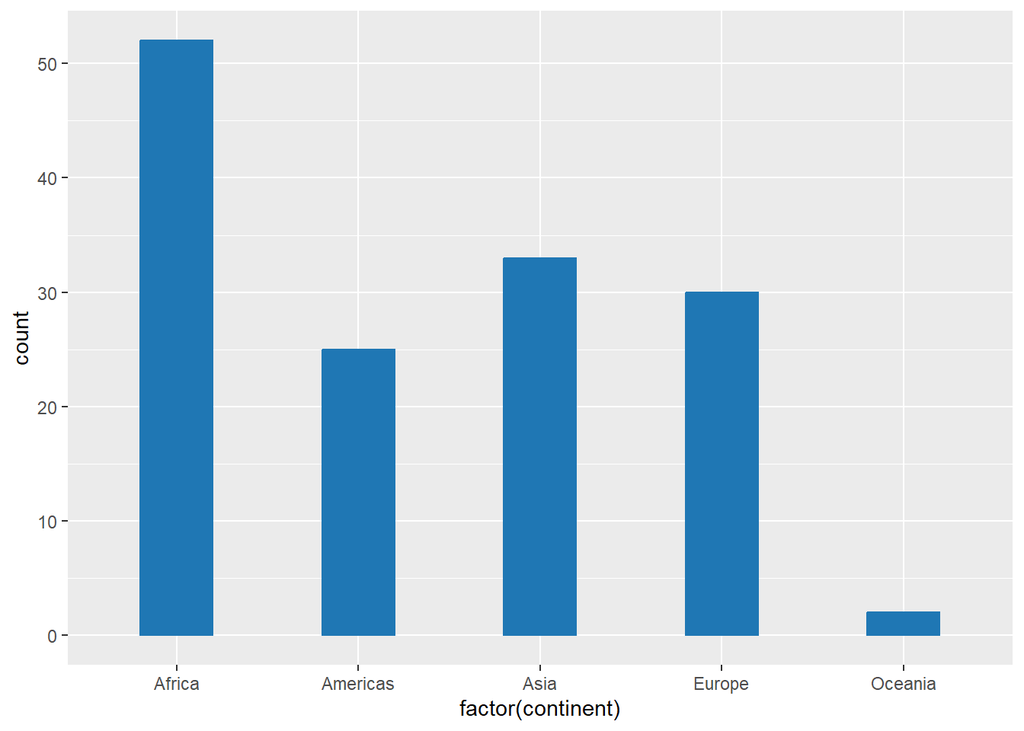

```r
# Create a bar chart using ggplot2
graph2 <- ggplot(data, aes(x = factor(continent))) +
#Add bars with a specified width and color
  geom_bar( width=0.4, color="#1f77b4", fill="#1f77b4")

graph2
```

# 5 Refine your style

- `labs(...)` → Adds a title, axis labels, and legend title.
- `scale_fill_manual(...)` → Defines custom colors for each continent category.
- `theme_minimal()` → Applies a clean, minimalistic theme.
- `theme(plot.title = element_text(...))` → Centers the title (hjust = 0.5), increases font size (`size = 14`), and makes it bold (`face = "bold"`).

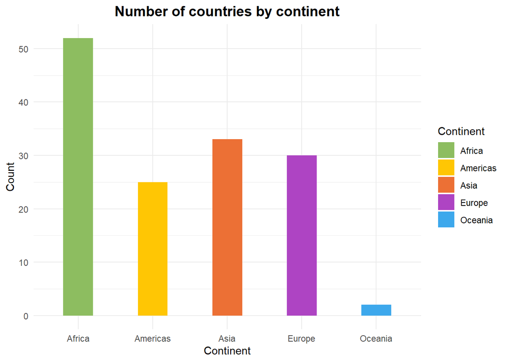

```r
# Create a bar chart using ggplot2
graph3 <- ggplot(data, aes(x = factor(continent), fill = factor(continent))) +
# Add bars with a specified width, automatically filled by continent category
  geom_bar(width=0.4) +
# Add labels for title, axes, and legend
  labs(title = "Number of countries by continent",
       x = "Continent",
       y = "Count",
       fill = "Continent") +
# Manually assign colors to each continent category
  scale_fill_manual(values = c("#8DBD60", "#FFC604", "#EC7035", "#AE44C3", "#3DA8EC")) +
# Apply a minimalistic theme
  theme_minimal() +
# Customize the title: center it, increase size, and make it bold
  theme(plot.title = element_text(hjust = 0.5, size = 14, face = "bold"))


graph3
```

Now, let’s implement additional enhancements to elevate the impact and quality of the visualization.

- `geom_text(...)` → Adds labels to bars with after_stat(count), placing them above the bars (`vjust = -0.5`), making them bold and increasing size (`size = 8`).
- `scale_color_manual(...)` → Ensures text labels match the fill color of the bars.
- `ylim(0, 60)` → Expands the Y-axis upper limit to avoid overlapping labels with the title.
- `axis.text.y = element_blank()` → Removes the y-axis text values.
- `axis.title.y = element_blank()` → Removes the y-axis title.
- `legend.position = "none"` → Hides the legend for text color.

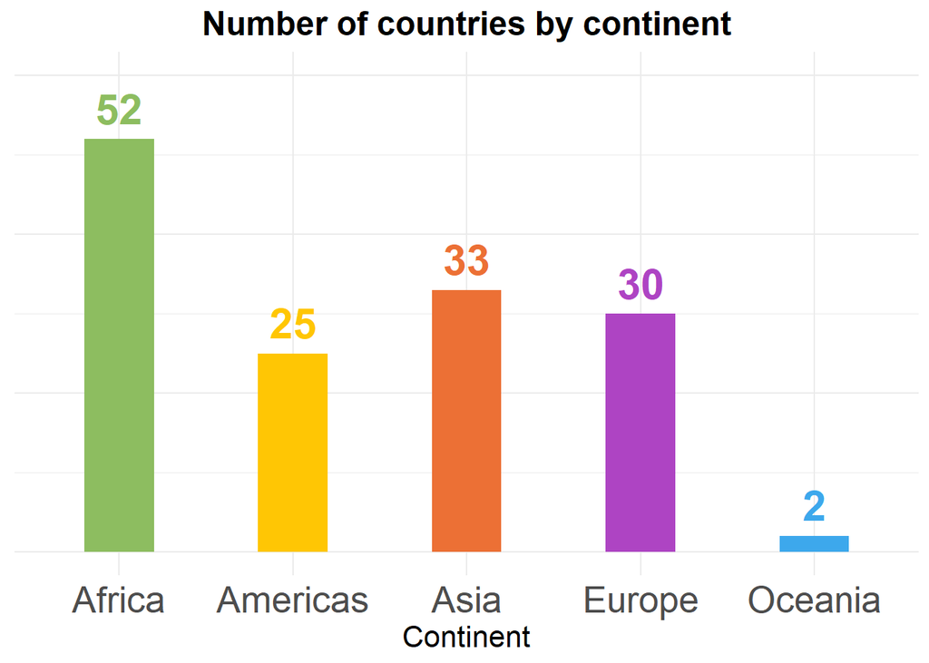

```r
# Create a bar chart using ggplot2
ggplot(data, aes(x = factor(continent), fill = factor(continent))) +
# Add bars with a specified width, automatically filled by continent category
  geom_bar(width = 0.4) +
# Add labels on top of the bars, matching the color of each bar
  geom_text(stat = "count", aes(label = after_stat(count), color = factor(continent)),
            vjust = -0.5, size = 8, fontface = "bold") +
# Add labels for title and axes
  labs(title = "Number of countries by continent",
       x = "Continent") +
# Manually assign colors to each continent category
  scale_fill_manual(values = c("#8DBD60", "#FFC604", "#EC7035", "#AE44C3", "#3DA8EC")) +
# Ensure that text labels match the bar colors
  scale_color_manual(values = c("#8DBD60", "#FFC604", "#EC7035", "#AE44C3", "#3DA8EC")) +
# Increase the upper limit of the Y-axis to prevent text from overlapping
  ylim(0, 60) +
# Apply a minimalistic theme
  theme_minimal() +
# Customize text appearance and remove unnecessary elements
  theme(plot.title = element_text(hjust = 0.5, size = 18, face = "bold"), # Center and enlarge the title
        axis.text.x = element_text(size = 20),  # Increase x-axis text size
        axis.text.y = element_blank(),  # Remove y-axis text
        axis.title.x = element_text(size = 16), # Increase x-axis title size
        axis.title.y = element_blank(), # Remove y-axis title
        legend.position = "none")  # Hide the legend
```

If you want to reorder the bars from largest to smallest, this code will help you.

`x = reorder(factor(continent), -table(continent)[factor(continent)])`

- `reorder()` → sorts the bars based on frequency.
- `table(continent)[factor(continent)]` → gets the count of each category.
- The negative sign `-` ensures that the bars are sorted from largest to smallest instead of smallest to largest.

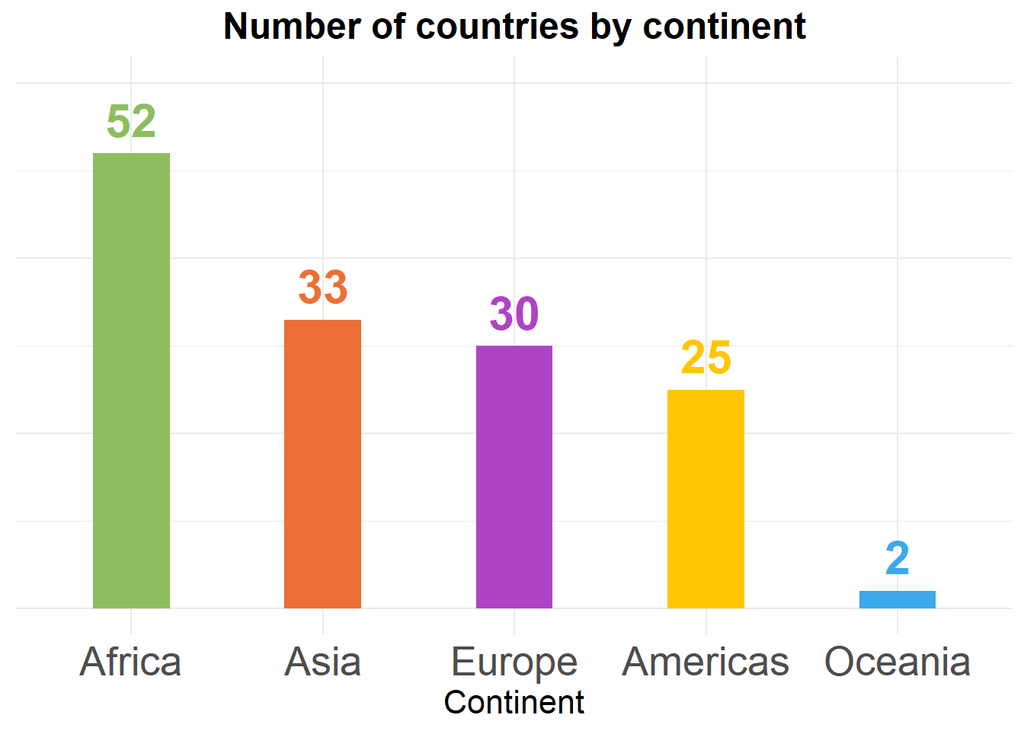

```r
# Create a bar chart using ggplot2
ggplot(data, aes(x = reorder(factor(continent), -table(continent)[factor(continent)]),
                 fill = factor(continent))) +
  # Add bars with a specified width, automatically filled by continent category
  geom_bar(width = 0.4) +
  # Add labels on top of the bars, matching the color of each bar
  geom_text(stat = "count", aes(label = after_stat(count), color = factor(continent)),
            vjust = -0.5, size = 8, fontface = "bold") +
  # Add labels for title, axes, and legend
  labs(title = "Number of countries by continent",
       x = "Continent",
       y = "Count",
       fill = "Cylinders") +  # (Possible typo: "Cylinders" instead of "Continent")
  # Manually assign colors to each continent category
  scale_fill_manual(values = c("#8DBD60", "#FFC604", "#EC7035", "#AE44C3", "#3DA8EC")) +
  # Ensure that text labels match the bar colors
  scale_color_manual(values = c("#8DBD60", "#FFC604", "#EC7035", "#AE44C3", "#3DA8EC")) +
  # Increase the upper limit of the Y-axis to prevent text from overlapping
  ylim(0, 60) +
  # Apply a minimalistic theme
  theme_minimal() +
  # Customize text appearance and remove unnecessary elements
  theme(plot.title = element_text(hjust = 0.5, size = 18, face = "bold"),  # Center and enlarge the title
        axis.text.x = element_text(size = 20),  # Increase x-axis text size
        axis.text.y = element_blank(),  # Remove y-axis text
        axis.title.x = element_text(size = 16),  # Increase x-axis title size
        axis.title.y = element_blank(),  # Remove y-axis title
        legend.position = "none")  # Hide the legend for text color
```

# 6 Advanced Bar Visualization Techniques

## 6.1 Advanced Visualization 1

In this section we will focus on th use of advance bar visualizaion tecniques for impactful data presentation. Will will develope a bargraph with

- `stat = "count"` → ensures that the points align with the bar heights.
- `size = 20` → makes the points large.
- `shape = 21` → allows using both fill and color attributes.
- `fill = "white"` → makes the points stand out from the bars.

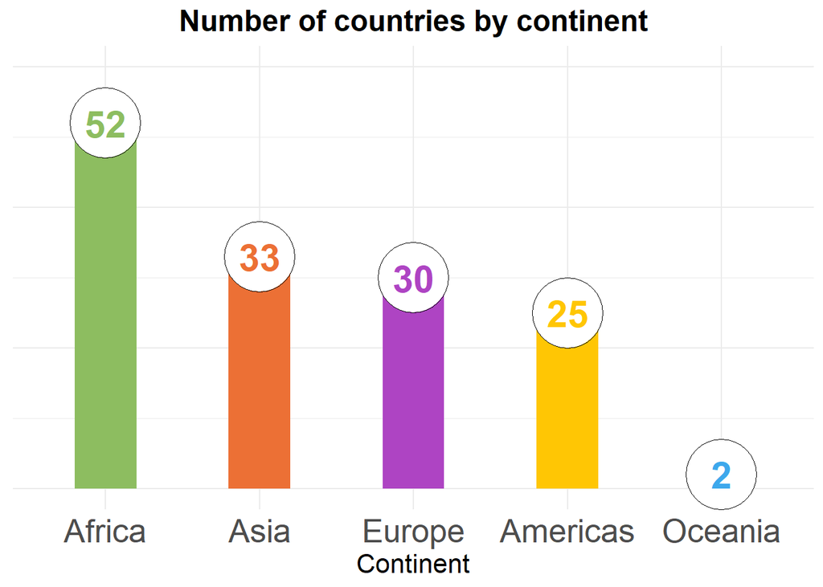

```r
# Create a bar chart using ggplot2
ggplot(data, aes(x = reorder(factor(continent), -table(continent)[factor(continent)]),
                 fill = factor(continent))) +
  # Add bars with a specified width, automatically filled by continent category
  geom_bar(width = 0.4) +
# Add white circular points at the center of each bar to enhance visualization
  geom_point(aes(y = after_stat(count)), stat = "count", size = 20, shape = 21, fill = "white") +
  # Add labels on top of the bars, matching the color of each bar
  geom_text(stat = "count", aes(label = after_stat(count), color = factor(continent)),
            vjust = 0.5, size = 8, fontface = "bold") +
  # Add labels for title, axes, and legend
  labs(title = "Number of countries by continent",
       x = "Continent",
       y = "Count",
       fill = "Cylinders") +  # (Possible typo: "Cylinders" instead of "Continent")
  # Manually assign colors to each continent category
  scale_fill_manual(values = c("#8DBD60", "#FFC604", "#EC7035", "#AE44C3", "#3DA8EC")) +
  # Ensure that text labels match the bar colors
  scale_color_manual(values = c("#8DBD60", "#FFC604", "#EC7035", "#AE44C3", "#3DA8EC")) +
  # Increase the upper limit of the Y-axis to prevent text from overlapping
  ylim(0, 60) +
  # Apply a minimalistic theme
  theme_minimal() +
  # Customize text appearance and remove unnecessary elements
  theme(plot.title = element_text(hjust = 0.5, size = 18, face = "bold"),  # Center and enlarge the title
        axis.text.x = element_text(size = 20),  # Increase x-axis text size
        axis.text.y = element_blank(),  # Remove y-axis text
        axis.title.x = element_text(size = 16),  # Increase x-axis title size
        axis.title.y = element_blank(),  # Remove y-axis title
        legend.position = "none")  # Hide the legend for text color
```

## 6.2 Advanced Visualization 2

We can change de shape inside geom_point() to make another type of viualization

`geom_point(aes(y = after_stat(count)- 5), stat = "count", size = 10, shape = 24, fill = "white", color="white")`

The warning below refers to the area of Oceania that is not shown in the graph because it is less than the coordinate assigned with `y = after_stat(count) - 5`.

```
## Warning: Removed 1 row containing missing values or values outside the scale range
## (`geom_point()`).
```

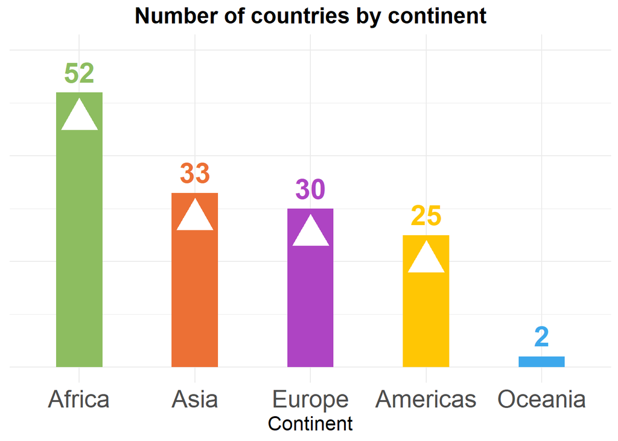

```r
# Create a bar chart using ggplot2
ggplot(data, aes(x = reorder(factor(continent), -table(continent)[factor(continent)]),
                 fill = factor(continent))) +
  # Add bars with a specified width, automatically filled by continent category
  geom_bar(width = 0.4) +
# Add white Triangle pointing upward at the center of each bar to enhance visualization
  geom_point(aes(y = after_stat(count) - 5), stat = "count", size = 10, shape = 24, fill = "white", color="white") +
  # Add labels on top of the bars, matching the color of each bar
  geom_text(stat = "count", aes(label = after_stat(count), color = factor(continent)),
            vjust = -0.5, size = 8, fontface = "bold") +
  # Add labels for title, axes, and legend
  labs(title = "Number of countries by continent",
       x = "Continent",
       y = "Count",
       fill = "Cylinders") +  # (Possible typo: "Cylinders" instead of "Continent")
  # Manually assign colors to each continent category
  scale_fill_manual(values = c("#8DBD60", "#FFC604", "#EC7035", "#AE44C3", "#3DA8EC")) +
  # Ensure that text labels match the bar colors
  scale_color_manual(values = c("#8DBD60", "#FFC604", "#EC7035", "#AE44C3", "#3DA8EC")) +
  # Increase the upper limit of the Y-axis to prevent text from overlapping
  ylim(0, 60) +
  # Apply a minimalistic theme
  theme_minimal() +
  # Customize text appearance and remove unnecessary elements
  theme(plot.title = element_text(hjust = 0.5, size = 18, face = "bold"),  # Center and enlarge the title
        axis.text.x = element_text(size = 20),  # Increase x-axis text size
        axis.text.y = element_blank(),  # Remove y-axis text
        axis.title.x = element_text(size = 16),  # Increase x-axis title size
        axis.title.y = element_blank(),  # Remove y-axis title
        legend.position = "none")  # Hide the legend for text color
```

## 6.3 Advanced Visualization 3

We can edit this graph a little more to obtain a completely different visualization

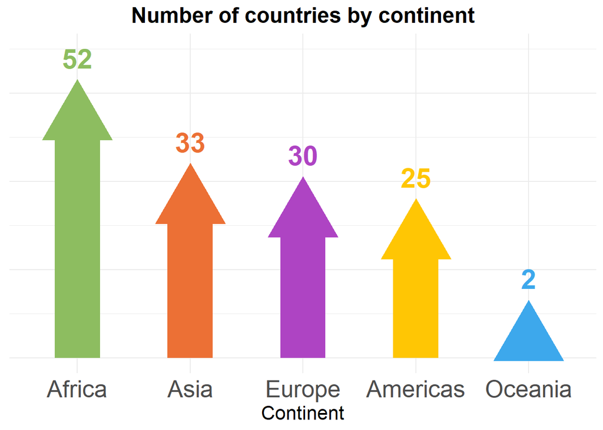

```r
# Create a bar chart using ggplot2
ggplot(data, aes(x = reorder(factor(continent), -table(continent)[factor(continent)]),
                 fill = factor(continent))) +
  # Add bars with a specified width, automatically filled by continent category
  geom_bar(width = 0.4) +
  # Add white Triangle pointing upward with the same color of the bars at the center of each bar to enhance visualization
  geom_point(aes(y = after_stat(count) + 2, fill = factor(continent), color = factor(continent)),
             stat = "count", size = 20, shape = 24) +
  #Add labels on top of the bars, matching the color of each bar
  geom_text(stat = "count", aes(label = after_stat(count), color = factor(continent)),
            vjust = -3, size = 8, fontface = "bold") +
  # Add labels for title, axes, and legend
  labs(title = "Number of countries by continent",
       x = "Continent",
       y = "Count",
       fill = "Cylinders") +  # (Possible typo: "Cylinders" instead of "Continent")
  # Manually assign colors to each continent category
  scale_fill_manual(values = c("#8DBD60", "#FFC604", "#EC7035", "#AE44C3", "#3DA8EC")) +
  # Ensure that text labels match the bar colors
  scale_color_manual(values = c("#8DBD60", "#FFC604", "#EC7035", "#AE44C3", "#3DA8EC")) +
  # Increase the upper limit of the Y-axis to prevent text from overlapping
  ylim(0, 70) +
  # Apply a minimalistic theme
  theme_minimal() +
  # Customize text appearance and remove unnecessary elements
  theme(plot.title = element_text(hjust = 0.5, size = 18, face = "bold"),  # Center and enlarge the title
        axis.text.x = element_text(size = 20),  # Increase x-axis text size
        axis.text.y = element_blank(),  # Remove y-axis text
        axis.title.x = element_text(size = 16),  # Increase x-axis title size
        axis.title.y = element_blank(),  # Remove y-axis title
        legend.position = "none")  # Hide the legend for text color
```

## 6.4 Advanced Visualization 4

We make some changes to the advanced visualization 1 to further enhance the impact of the graphs:

`geom_point(aes(y = after_stat(count) + 8, color = factor(continent)),` `stat = "count", size = 20, shape = 21, fill = "white")`

- `vjust = -1.5` in `geom_text()` → Moves the labels 1.5 units above the top of each bar, preventing overlap with the points.
- `ylim(0, 65)` → Extends the upper limit to 65, preventing labels and points from being cut off at the top.

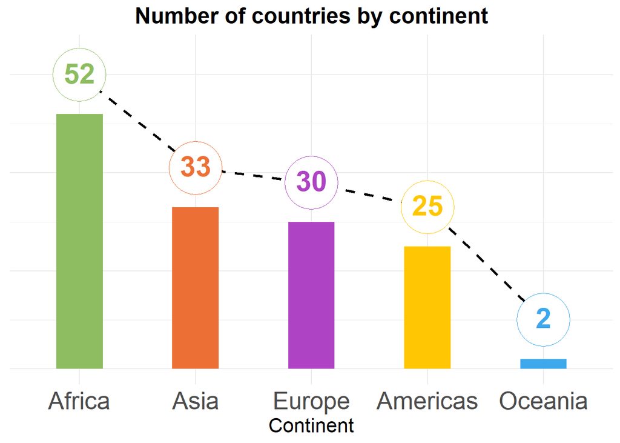

```r
# Create a bar chart using ggplot2

ggplot(data, aes(x = reorder(factor(continent), -table(continent)[factor(continent)]),
                 fill = factor(continent))) +
  # Add bars with a specified width, automatically filled by continent category
  geom_bar(width = 0.4) +
# Add a line that connects each geom_point  to enhance visualization
    geom_line(aes(y = after_stat(count) + 8, group = 1), stat = "count", linetype = "dashed", color = "black", linewidth = 1) +
# Add white circular points above of each bar to enhance visualization
  geom_point(aes(y = after_stat(count) + 8, color = factor(continent)), stat = "count", size = 20, shape = 21, fill = "white") +
  # Add labels on top of the bars, matching the color of each bar
  geom_text(stat = "count", aes(label = after_stat(count), color = factor(continent)),
            vjust = -1.5, size = 8, fontface = "bold") +
  # Add labels for title, axes, and legend
  labs(title = "Number of countries by continent",
       x = "Continent",
       y = "Count") +
  # Manually assign colors to each continent category
  scale_fill_manual(values = c("#8DBD60", "#FFC604", "#EC7035", "#AE44C3", "#3DA8EC")) +
  # Ensure that text labels match the bar colors
  scale_color_manual(values = c("#8DBD60", "#FFC604", "#EC7035", "#AE44C3", "#3DA8EC")) +
  # Increase the upper limit of the Y-axis to prevent text from overlapping
  ylim(0, 65) +
  # Apply a minimalistic theme
  theme_minimal() +
  # Customize text appearance and remove unnecessary elements
  theme(plot.title = element_text(hjust = 0.5, size = 18, face = "bold"),  # Center and enlarge the title
        axis.text.x = element_text(size = 20),  # Increase x-axis text size
        axis.text.y = element_blank(),  # Remove y-axis text
        axis.title.x = element_text(size = 16),  # Increase x-axis title size
        axis.title.y = element_blank(),  # Remove y-axis title
        legend.position = "none")  # Hide the legend for text color
```

## 6.5 Advanced Visualization 5

Now let’s create a different style. We modified various objects in the code, but the most relevant changes were:

Adding `stroke = 2` to the existing `geom_point()`:

`geom_point(aes(y = after_stat(count) + 8, color = factor(continent)),` `stat = "count", size = 10, shape = 21, fill = "white", stroke = 2)`

Adding a second `geom_point()` to create the inner part of the circle

`geom_point(aes(y = after_stat(count) + 8, color = factor(continent),` `fill = factor(continent)), stat = "count", size = 6, shape = 21)`

Try to identify the others changes!

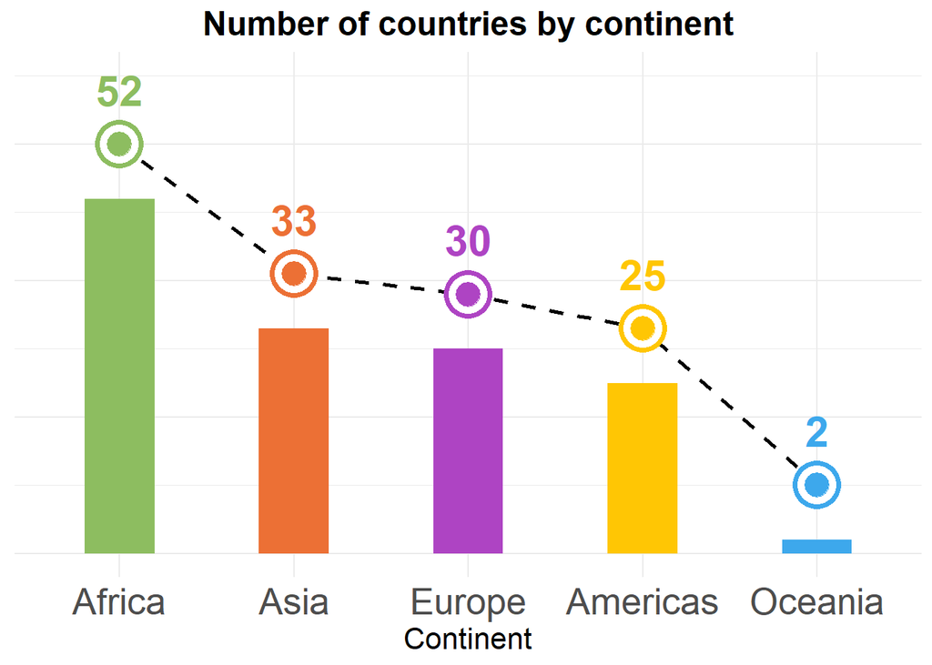

```r
# Create a bar chart using ggplot2

ggplot(data, aes(x = reorder(factor(continent), -table(continent)[factor(continent)]),
                 fill = factor(continent))) +
  # Add bars with a specified width, automatically filled by continent category
  geom_bar(width = 0.4) +
# Add a line that connects each geom_point  to enhance visualization
    geom_line(aes(y = after_stat(count) + 8, group = 1), stat = "count", linetype = "dashed", color = "black", linewidth = 1) +
# Add white firts circular points above of each bar to enhance visualization
  geom_point(aes(y = after_stat(count) + 8, color = factor(continent)), stat = "count", size = 10, shape = 21, fill = "white", stroke = 2) +
# Second point (inner layer of the color of each bar)
  geom_point(aes(y = after_stat(count) + 8, color = factor(continent), fill = factor(continent)),  stat = "count", size = 6, shape = 21) +

  # Add labels on top of the bars, matching the color of each bar
  geom_text(stat = "count", aes(label = after_stat(count), color = factor(continent)),
            vjust = -3, size = 8, fontface = "bold") +
  # Add labels for title, axes, and legend
  labs(title = "Number of countries by continent",
       x = "Continent",
       y = "Count") +
  # Manually assign colors to each continent category
  scale_fill_manual(values = c("#8DBD60", "#FFC604", "#EC7035", "#AE44C3", "#3DA8EC")) +
  # Ensure that text labels match the bar colors
  scale_color_manual(values = c("#8DBD60", "#FFC604", "#EC7035", "#AE44C3", "#3DA8EC")) +
  # Increase the upper limit of the Y-axis to prevent text from overlapping
  ylim(0, 70) +
  # Apply a minimalistic theme
  theme_minimal() +
  # Customize text appearance and remove unnecessary elements
  theme(plot.title = element_text(hjust = 0.5, size = 18, face = "bold"),  # Center and enlarge the title
        axis.text.x = element_text(size = 20),  # Increase x-axis text size
        axis.text.y = element_blank(),  # Remove y-axis text
        axis.title.x = element_text(size = 16),  # Increase x-axis title size
        axis.title.y = element_blank(),  # Remove y-axis title
        legend.position = "none")  # Hide the legend for text color
```

## 6.6 Advanced Visualization 6

Now let’s explore a truly innovative visualization (at least within R). Instead of using names for each continent, we will incorporate images (maps) to represent them using the `geom_image()` function from the `ggimage` package. To achieve this, we need to make some additional modifications. Firstly, note that `geom_image()` does not support the `stat="count"` feature utilized by `geom_bar()`, so we must calculate the counts before creating the graph. Let’s proceed with that and assign each continent its corresponding image. Remember, all images must be in the working directory selected in R.

```r
#install.packages("ggimage")

library(ggimage)

library(dplyr)

data_counts <- data %>%
  count(continent) %>%
  mutate(image = case_when(
    continent == "Africa" ~ "Africa.png",
    continent == "Americas" ~ "Americas.png",
    continent == "Asia" ~ "Asia.png",
    continent == "Europe" ~ "Europe.png",
    continent == "Oceania" ~ "Oceania.png"

  ))

data_counts
```

```
## # A tibble: 5 × 3
##   continent     n image
##   <fct>     <int> <chr>
## 1 Africa       52 Africa.png
## 2 Americas     25 Americas.png
## 3 Asia         33 Asia.png
## 4 Europe       30 Europe.png
## 5 Oceania       2 Oceania.png
```

Once you have calculated the counts, you can proceed with creating the graph. Let’s break down each part of the code to help you understand what is happening and to review the content we’ve covered so far.

- **Using Precomputed Counts** Previously, counts were calculated inside the plot using `stat = "count"`. Now, the dataset already includes a column n with precomputed values, so `stat = "identity"` is used in `geom_bar()`.

  ```
  ggplot(data_counts, aes(x = reorder(factor(continent), -n), y = n, fill = factor(continent))) +
  geom_bar(stat = "identity", width = 0.4)
  ```

  - `y = n` → Uses the precomputed count values directly.
  - `stat = "identity"` → Indicates that y already contains the desired values.
  - `reorder(factor(continent), -n)` → Orders continents from highest to lowest count.
  - `width = 0.4` → Adjusts bar width.
- **Adding a Line Connecting Points**

  ```
  geom_line(aes(y = n + 8, group = 1), linetype = "dashed", color = "black", linewidth = 1) +
  ```

  - Purpose: Highlights the overall trend by connecting points at the top of each bar.
  - `y = n + 8` → Elevates the line above the bars.
  - `group = 1` → Ensures the points are properly connected.
  - `linetype = "dashed"` → Uses a dashed line style.
- **Adding White Points on Top of the Bars**

  ```
  geom_point(aes(y = n + 8, color = factor(continent)), size = 20, shape = 21, fill = "white") +
  ```

  ```
  geom_image(data = data_counts, aes(y = -6, image = image), size = 0.15) +
  ```

  - Purpose: Adds continent-related images at the bottom of each bar.
  - `data = data_counts` → Uses the dataset containing the image column.
  - `y = -6` → Positions images below the bars.
  - `image = image` → Specifies the column with image paths.
  - `size = 0.15` → Adjusts image size.
- **Customizing the Design**

```
ylim(-10, 65) +
theme_minimal() +
theme(plot.title = element_text(hjust = 0.5, size = 18, face = "bold"),
      axis.text.x = element_blank(),
      axis.text.y = element_blank(),
      axis.title.x = element_text(size = 16),
      axis.title.y = element_blank(),
      legend.position = "none",
      panel.grid = element_blank()  # Removes grid lines
)
```

**And the final product is:**

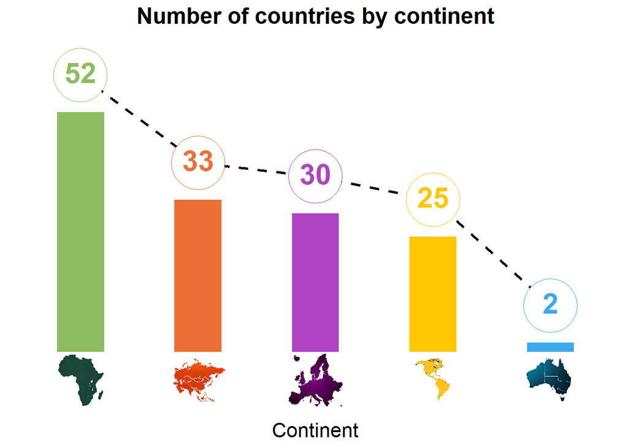

```r
ggplot(data_counts, aes(x = reorder(factor(continent), -n), y = n, fill = factor(continent))) +
  # Bars
  geom_bar(stat = "identity", width = 0.4) +
  # Line connecting points
  geom_line(aes(y = n + 8, group = 1), linetype = "dashed", color = "black", linewidth = 1) +
  # White points on top of each bar
  geom_point(aes(y = n + 8, color = factor(continent)), size = 20, shape = 21, fill = "white") +
  # Count labels
  geom_text(aes(label = n, y = n , color = factor(continent)), vjust = -1.4, size = 8, fontface = "bold") +
  # Images at the base of the bars
  geom_image(data = data_counts, aes(y = -6, image = image), size = 0.15) +
  # Labels and scales
  labs(title = "Number of countries by continent",
       x = "Continent",
       y = "Count") +
  scale_fill_manual(values = c("#8DBD60", "#FFC604", "#EC7035", "#AE44C3", "#3DA8EC")) +
  scale_color_manual(values = c("#8DBD60", "#FFC604", "#EC7035", "#AE44C3", "#3DA8EC")) +
  ylim(-10, 65) +
  # Minimalist theme with customizations
  theme_minimal() +
  theme(plot.title = element_text(hjust = 0.5, size = 18, face = "bold"),
        axis.text.x = element_blank(),
        axis.text.y = element_blank(),
        axis.title.x = element_text(size = 16),
        axis.title.y = element_blank(),
        legend.position = "none",
        panel.grid = element_blank()  # Removes grid lines
  )
```

# 7 Interactive visualizations

Now, we will enhance even more our visualizations by adding interactivity to the graph using the `ggplotly()` function from the `plotly` package. Let’s review three examples of these interactive visualizations.

## 7.1 Basic interactive visualization

To make your ggplot interactive using `ggplotly()`, we need to:

- **Add a tooltip using aes(text = …) in geom_bar()**
  - We create a tooltip with two labels:
    - In `geom_bar()`, we include `aes(text = paste("Continent:", continent, "<br>Countries:", n))`. This creates a custom tooltip that displays the continent name (continent) and number of countries (n). `<br>` is used for a line break in Plotly tooltips.
    - This text will appear when hovering over each bar in the interactive plot.
- **Wrap the ggplot inside ggplotly()**
  - `ggplotly(p, tooltip = "text")` → This will make the plot interactive.
  - `tooltip = "text"` → ensures that only our custom labels appear when hovering. Tells Plotly to only use the text aesthetic for tooltips.

```r
library(plotly)

# Create ggplot with tooltip information
p <- ggplot(data_counts, aes(x = reorder(factor(continent), -n), y = n, fill = factor(continent))) +
  # Add bars with precomputed counts and tooltip
  geom_bar(stat = "identity", width = 0.4, aes(text = paste("Continent:", continent, "<br>Countries:", n))) +
  # Add white Triangle pointing upward with the same color of the bars at the center of each bar to enhance visualization
  geom_point(aes(y = n + 2, fill = factor(continent), color = factor(continent)), size = 20, shape = 24) +
  # Add labels for title and y-axis
  labs(title = "Number of countries by continent",
       y = "Count",
       x = "Continent") +
  # Manually assign colors to each continent category
  scale_fill_manual(values = c("#8DBD60", "#FFC604", "#EC7035", "#AE44C3", "#3DA8EC")) +
  # Ensure that markers match the bar colors
  scale_color_manual(values = c("#8DBD60", "#FFC604", "#EC7035", "#AE44C3", "#3DA8EC")) +
  # Adjust y-axis limits
  ylim(0, 70) +
  # Apply a minimalistic theme
  theme_minimal() +
  # Customize text appearance and remove unnecessary elements
  theme(plot.title = element_text(hjust = 0.5, size = 18, face = "bold"),  # Center and enlarge the title
        axis.text.x = element_text(size = 20),  # Increase x-axis text size
        axis.text.y = element_blank(),  # Remove y-axis text
        axis.title.x = element_text(size = 16),  # Increase x-axis title size
        axis.title.y = element_blank(),  # Remove y-axis title
        legend.position = "none")  # Hide the legend for text color

# Convert to an interactive plot
ggplotly(p, tooltip = "text")
```

[interactive chart not shown]

## 7.2 Improving Tooltip Quality

If you notice, the tooltips currently only appear when you hover over the bars, not the triangles. To ensure the tooltips appear when hovering over both the bars and the triangles, we need to:

- Add the `aes(text = ...)` inside both `geom_bar()` and `geom_point()`. This ensures that the tooltip information is attached to both layers.
- Modify `ggplotly()` to ensure tooltips work for both layers
- The `tooltip = "text"` argument will apply to both elements.

```r
# Create ggplot with tooltip information for both bars and triangles
p <- ggplot(data_counts, aes(x = reorder(factor(continent), -n), y = n, fill = factor(continent))) +
  # Add bars with tooltip
  geom_bar(stat = "identity", width = 0.4, aes(text = paste("Continent:", continent, "<br>Countries:", n))) +
  # Add triangles with the same tooltip
  geom_point(aes(y = n + 2, fill = factor(continent), color = factor(continent),
                 text = paste("Continent:", continent, "<br>Countries:", n)),
             size = 20, shape = 24) +
  # Add labels for title and y-axis
  labs(title = "Number of countries by continent",
       y = "Count",
       x = "Continent") +
  # Manually assign colors to each continent category
  scale_fill_manual(values = c("#8DBD60", "#FFC604", "#EC7035", "#AE44C3", "#3DA8EC")) +
  # Ensure that markers match the bar colors
  scale_color_manual(values = c("#8DBD60", "#FFC604", "#EC7035", "#AE44C3", "#3DA8EC")) +
  # Adjust y-axis limits
  ylim(0, 70) +
  # Apply a minimalistic theme
  theme_minimal() +
  # Customize text appearance and remove unnecessary elements
  theme(plot.title = element_text(hjust = 0.5, size = 18, face = "bold"),  # Center and enlarge the title
        axis.text.x = element_text(size = 20),  # Increase x-axis text size
        axis.text.y = element_blank(),  # Remove y-axis text
        axis.title.x = element_text(size = 16),  # Increase x-axis title size
        axis.title.y = element_blank(),  # Remove y-axis title
        legend.position = "none")  # Hide the legend for text color

# Convert to an interactive plot
ggplotly(p, tooltip = "text")
```

[interactive chart not shown]

## 7.3 Let’s take visualizations to the next level of quality.

Now, let’s add the icons of the continents to our interactive visualization. With this technique, we can create a more infographic-style presentation.

There are the most relevant changes:

- `ylim(-10, 70)` → Adjust the y-axis limits to accommodate the images that we are going to add later.
- **Extract x-axis positions for each continent category (x_positions vector)**

```
x_positions <- as.numeric(factor(data_counts$continent, levels = unique(data_counts$continent)))
```

- It creates a numeric vector that represents the x-axis positions of each continent.
- This step is crucial because `Plotly` requires numeric x-coordinates to place objects (such as images) at specific locations on the plot.
- Without this conversion, the images would not align correctly with the corresponding bars.
- Code breakdown:
  - Since `data_counts$continent` is a categorical variable (e.g., “Asia”, “Europe”, “Africa”), it is converted into a factor.
  - `levels = unique(data_counts$continent)` ensures that the factor levels are assigned based on the unique order of continents appearing in data_counts$continent.
  - `as.numeric(...)` transforms the factor into numbers corresponding to each continent. Factors in R are internally stored as numeric values (e.g., 1 for the first level, 2 for the second, etc.).
- **Create a list of images (icons) to be placed below each bar**
  - `lapply(...)` iterates over the index of each continent in data_counts$continent.
  - For each continent, it creates a list that defines an image to be added to the Plotly layout.
  - Code breakdown:
    - `source = image_urls[[data_counts$continent[i]]]` → Retrieves the correct image URL corresponding to the continent from the image_urls list.
    - `x = x_positions[i]` → Places the image at the correct x-coordinate (aligned with the bars).
    - `y = -1` → Positions the image slightly below the bars (negative y-value ensures it is below).
    - `sizex = 0.4, sizey = 12` → Adjusts the size of the image for proper visualization.
    - `xref = "x", yref = "y"` → Ensures the image follows the x and y axes of the plot.
    - `xanchor = "center", yanchor = "top"` → Centers the image horizontally under the corresponding bar.
    - `layer = "below"` → Places the image below the bars to avoid overlap.

```r
# Coordinates for images in the interactive graph
image_urls <- list(
  "Africa"  = "https://alejandrasarria.github.io/TheDataCanvas/sources/Africa.png",
  "Asia"    = "https://alejandrasarria.github.io/TheDataCanvas/sources/Asia.png",
  "Europe"  = "https://alejandrasarria.github.io/TheDataCanvas/sources/Europe.png",
  "America" = "https://alejandrasarria.github.io/TheDataCanvas/sources/Americas.png",
  "Oceania" = "https://alejandrasarria.github.io/TheDataCanvas/sources/Oceania.png"
)



# Create ggplot with tooltip information for both bars and triangles
p <- ggplot(data_counts, aes(x = reorder(factor(continent), -n), y = n, fill = factor(continent))) +
  # Add bars with tooltip
  geom_bar(stat = "identity", width = 0.4, aes(text = paste("Continent:", continent, "<br>Countries:", n))) +
  # Add triangles with the same tooltip
  geom_point(aes(y = n + 2, fill = factor(continent), color = factor(continent),
                 text = paste("Continent:", continent, "<br>Countries:", n)),
             size = 20, shape = 24) +
  # Add labels for title and x-axis
  labs(title = "Number of countries by continent",
       x = "Continent") +
  # Manually assign colors to each continent category
  scale_fill_manual(values = c("#8DBD60", "#FFC604", "#EC7035", "#AE44C3", "#3DA8EC")) +
  # Ensure that the triangle markers match the bar colors
  scale_color_manual(values = c("#8DBD60", "#FFC604", "#EC7035", "#AE44C3", "#3DA8EC")) +
# Adjust the y-axis limits to accommodate the images that we ar going to add later
  ylim(-10, 70) +
  # Apply a minimalistic theme
  theme_minimal() +
  # Customize text appearance and remove unnecessary elements
  theme(plot.title = element_text(hjust = 0.5, size = 18, face = "bold"),  # Center and enlarge the title
        axis.text.x = element_blank(),  # Remove x-axis text
        axis.text.y = element_blank(),  # Remove y-axis text
        axis.title.x = element_text(size = 16),  # Increase x-axis title size
        axis.title.y = element_blank(),  # Remove y-axis title
        legend.position = "none", # Remove the legend
        panel.grid = element_blank()  # Removes grid lines
)  # Hide the legend for text color


# Convert the ggplot object to an interactive plotly visualization
p_plotly <- ggplotly(p, tooltip = "text")

# Extract x-axis positions for each continent category
x_positions <- as.numeric(factor(data_counts$continent, levels = unique(data_counts$continent)))

# Print x-coordinates for debugging purposes.
#print(x_positions)  # Debería ser algo como: [1 2 3 4 5]

# Create a list of images (icons) to be placed below each bar
image_list <- lapply(1:length(data_counts$continent), function(i) {
  list(
    source = image_urls[[data_counts$continent[i]]],  # Correct image
    x = x_positions[i],  # # Set the correct x-coordinate
    y = -1,  #  Position slightly below the bars
    sizex = 0.4, sizey = 12,  # Adjust image size
    xref = "x", yref = "y", # Reference the x and y axes
    xanchor = "center", yanchor = "top", # Center the image horizontally
    layer = "below"  # Ensure images do not overlap the bars
  )
})

# Adjust the layout to properly display the images and set y-axis limits
p_plotly <- p_plotly %>% layout(
  images = image_list,
  yaxis = list(range = c(-10, max(data_counts$n) + 10))  # Extend y-axis range for better visualization
)

# Display the final interactive plot
p_plotly
```

[interactive chart not shown]